# EDLD 610: Functional Programming Midterm

Stephanie Gluck

5/3/2020

```r
knitr::opts_chunk$set(cache = TRUE)

library(tidyverse)
library(ggtext)
library(janitor)
library(glue)
```

## Part A: Data

### 1. Use the function to download all the data from 2014-15 to each of the past 4 school years and bind it into a single data frame, using a single function (i.e., one line of code). Note, this may take a minute or two to run, depending on your Internet speed.

```r
download_file <- function(year) {
    link <- glue::glue("https://www.oregon.gov/ode/educator-resources/assessment/TestResults20{year}/pagr_schools_ela_raceethnicity_{year-1}{year}.xlsx")
    rio::import(link, setclass = "tibble", na = c("-", "--", "*"))
}
```

```r
years <- 15:18

# loop through years, apply download file function
data <- map_df(years, ~download_file(.x)) %>%
  janitor::clean_names()

#OR this also works:
# map_df(years, download_file)
```

Conduct some basic data cleaning to make your data file look like the following.

Filter for only student groups coded as “White” or “Hispanic/Latino”. Select variables related to the number of students in each of the levels (1:4), and not percentages or collapsed levels. Remove any row that has missing data in any of the n variables

```r
names(data)
```

```
##  [1] "academic_year"                   "district_id"
##  [3] "district"                        "school_id"
##  [5] "school"                          "subject"
##  [7] "student_group"                   "grade_level"
##  [9] "number_proficient_level_3_or_4"  "percent_proficient_level_3_or_4"
## [11] "number_level_4"                  "percent_level_4"
## [13] "number_level_3"                  "percent_level_3"
## [15] "number_level_2"                  "percent_level_2"
## [17] "number_level_1"                  "percent_level_1"
## [19] "number_of_participants"          "participation_rate"
## [21] "number_proficient"
```

```r
td <- data %>%
  pivot_longer(contains("number_level"),
  names_to = "level",
  values_to = "n") %>%
  mutate(level = str_extract(level, "[0-9]")) %>%
  select(academic_year, district, school, student_group, grade_level, level, n) %>%
  filter(student_group == "Hispanic/Latino" |
           student_group == "White") %>%
  drop_na()

td
```

```
## # A tibble: 90,576 x 7
##    academic_year district   school         student_group grade_level level     n
##    <chr>         <chr>      <chr>          <chr>         <chr>       <chr> <dbl>
##  1 2014-2015     Adrian SD~ Adrian Elemen~ Hispanic/Lat~ Grade 3     4         1
##  2 2014-2015     Adrian SD~ Adrian Elemen~ Hispanic/Lat~ Grade 3     3         2
##  3 2014-2015     Adrian SD~ Adrian Elemen~ Hispanic/Lat~ Grade 3     2         1
##  4 2014-2015     Adrian SD~ Adrian Elemen~ Hispanic/Lat~ Grade 3     1         2
##  5 2014-2015     Adrian SD~ Adrian Elemen~ Hispanic/Lat~ Grade 6     4         0
##  6 2014-2015     Adrian SD~ Adrian Elemen~ Hispanic/Lat~ Grade 6     3         2
##  7 2014-2015     Adrian SD~ Adrian Elemen~ Hispanic/Lat~ Grade 6     2         3
##  8 2014-2015     Adrian SD~ Adrian Elemen~ Hispanic/Lat~ Grade 6     1         2
##  9 2014-2015     Adrian SD~ Adrian Elemen~ Hispanic/Lat~ Grade 7     4         0
## 10 2014-2015     Adrian SD~ Adrian Elemen~ Hispanic/Lat~ Grade 7     3         2
## # ... with 90,566 more rows
```

### 2. (5 points) Collapse (sum) the n across grades and school for each district within each academic year, student group, and level. At the same time, calulate the number of schools (unique schools listed) for each district. Also move your data to a wider format where the student groups become new columns, filled by the district n. Remove districts that did not report numbers for one or both student groups (i.e., drop missing data from the new columns). Your data frame should look like the below

```r
str(td)
```

```
## tibble [90,576 x 7] (S3: tbl_df/tbl/data.frame)
##  $ academic_year: chr [1:90576] "2014-2015" "2014-2015" "2014-2015" "2014-2015" ...
##  $ district     : chr [1:90576] "Adrian SD 61" "Adrian SD 61" "Adrian SD 61" "Adrian SD 61" ...
##  $ school       : chr [1:90576] "Adrian Elementary School" "Adrian Elementary School" "Adrian Elementary School" "Adrian Elementary School" ...
##  $ student_group: chr [1:90576] "Hispanic/Latino" "Hispanic/Latino" "Hispanic/Latino" "Hispanic/Latino" ...
##  $ grade_level  : chr [1:90576] "Grade 3" "Grade 3" "Grade 3" "Grade 3" ...
##  $ level        : chr [1:90576] "4" "3" "2" "1" ...
##  $ n            : num [1:90576] 1 2 1 2 0 2 3 2 0 2 ...
```

```r
names(td)
```

```
## [1] "academic_year" "district"      "school"        "student_group"
## [5] "grade_level"   "level"         "n"
```

```r
#create 2 separate df and join them together
#unique schools

unique_school <- td %>%
  group_by(district) %>%
  summarise(n_schools = length(unique(school))) %>%
  ungroup()

#number of students (n)
students <- td %>%
  group_by(district, academic_year, student_group, level) %>%
  summarise(n = sum(n)) %>%
  pivot_wider(names_from = student_group,
              values_from = n) %>%
  janitor::clean_names() %>%
  ungroup()

#join the 2 df together, drop NA, re-order the columns
td2 <- left_join(students, unique_school) %>%
  drop_na() %>%
  select(academic_year, district, n_schools, level, hispanic_latino, white)
td2
```

```
## # A tibble: 1,948 x 6
##    academic_year district     n_schools level hispanic_latino white
##    <chr>         <chr>            <int> <chr>           <dbl> <dbl>
##  1 2014-2015     Adrian SD 61         2 1                   6     8
##  2 2014-2015     Adrian SD 61         2 2                   6    17
##  3 2014-2015     Adrian SD 61         2 3                   6    23
##  4 2014-2015     Adrian SD 61         2 4                   1    22
##  5 2015-2016     Adrian SD 61         2 1                   5     4
##  6 2015-2016     Adrian SD 61         2 2                   3    15
##  7 2015-2016     Adrian SD 61         2 3                   5    39
##  8 2015-2016     Adrian SD 61         2 4                   0    36
##  9 2016-2017     Adrian SD 61         2 1                   2     4
## 10 2016-2017     Adrian SD 61         2 2                   0    19
## # ... with 1,938 more rows
```

## Part B: Acheivement Gaps

### 1. (10 points) Estimate an achievement gap effect size for every school district in the state that reported data on both student groups (i.e., using the data we created above), for each academic year. Note, on my computer this took about 38 seconds. It will likely take a bit longer for you, but shouldn’t take too long. You may get a warning. Just go ahead and ignore that for now.

```r
library(gapr)

#nest data by year and district
by_district <- td2 %>%
    nest(-district, -academic_year, -n_schools)
```

```
## Warning: All elements of `...` must be named.
## Did you want `data = c(level, hispanic_latino, white)`?
```

```r
by_district
```

```
## # A tibble: 487 x 4
##    academic_year district     n_schools data
##    <chr>         <chr>            <int> <list>
##  1 2014-2015     Adrian SD 61         2 <tibble [4 x 3]>
##  2 2015-2016     Adrian SD 61         2 <tibble [4 x 3]>
##  3 2016-2017     Adrian SD 61         2 <tibble [4 x 3]>
##  4 2017-2018     Adrian SD 61         2 <tibble [4 x 3]>
##  5 2014-2015     Amity SD 4J          3 <tibble [4 x 3]>
##  6 2015-2016     Amity SD 4J          3 <tibble [4 x 3]>
##  7 2016-2017     Amity SD 4J          3 <tibble [4 x 3]>
##  8 2017-2018     Amity SD 4J          3 <tibble [4 x 3]>
##  9 2016-2017     Annex SD 29          1 <tibble [4 x 3]>
## 10 2014-2015     Ashland SD 5         6 <tibble [4 x 3]>
## # ... with 477 more rows
```

```r
#run achievement gap effect size and extract auc, v and v_se
results_by_district <- by_district %>%
  mutate(gap = map(data, ~estimate_v("white", "hispanic_latino",
                                  data = .x))) %>%
  select(-data) %>%
  unnest(gap)
```

### 2. (10 points) The plot below shows the achievement gap estimate for one school district across years. Produce a similar plot to the below for each of the first 100 school districts. Make sure you don’t miss the caption noting the number of schools in the district.

Hint: You need to select unique districts.

```r
dists <- unique(results_by_district$district)[1:100]

pd <- results_by_district %>%
  filter(district %in% dists)

unique(pd$district)
```

```
##   [1] "Adrian SD 61"                    "Amity SD 4J"
##   [3] "Annex SD 29"                     "Ashland SD 5"
##   [5] "Astoria SD 1"                    "Athena-Weston SD 29RJ"
##   [7] "Baker SD 5J"                     "Bandon SD 54"
##   [9] "Banks SD 13"                     "Beaverton SD 48J"
##  [11] "Bend-LaPine Administrative SD 1" "Bethel SD 52"
##  [13] "Brookings-Harbor SD 17C"         "Butte Falls SD 91"
##  [15] "Canby SD 86"                     "Cascade SD 5"
##  [17] "Centennial SD 28J"               "Central Curry SD 1"
##  [19] "Central Linn SD 552"             "Central Point SD 6"
##  [21] "Central SD 13J"                  "Clatskanie SD 6J"
##  [23] "Coos Bay SD 9"                   "Coquille SD 8"
##  [25] "Corbett SD 39"                   "Corvallis SD 509J"
##  [27] "Creswell SD 40"                  "Crook County SD"
##  [29] "Culver SD 4"                     "Dallas SD 2"
```

[output cut: 35 more lines]

```r
#to examine number of rows
pd %>% count(district)
```

```
## # A tibble: 100 x 2
##    district                  n
##    <chr>                 <int>
##  1 Adrian SD 61              4
##  2 Amity SD 4J               4
##  3 Annex SD 29               1
##  4 Ashland SD 5              4
##  5 Astoria SD 1              4
##  6 Athena-Weston SD 29RJ     4
##  7 Baker SD 5J               4
##  8 Bandon SD 54              4
##  9 Banks SD 13               4
## 10 Beaverton SD 48J          4
## # ... with 90 more rows
```

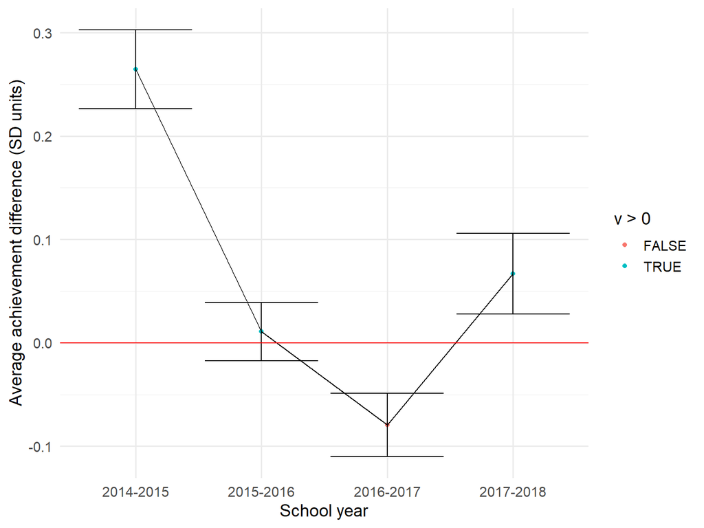

```r
theme_set(theme_minimal(14))

#create one plot first
# as.factor() makes acacdemic year a factor; then can call as.numeric() on this to make academic_year numeric in order to connect via geam_line:
pd %>% filter(district == "Bandon SD 54") %>%
  ggplot(aes(academic_year, v)) +
  geom_point(aes(color = v > 0)) +
  geom_line(aes(x = as.numeric(as.factor(academic_year)))) +
  geom_errorbar(aes(ymin = v - v_se, ymax = v + v_se)) +
  geom_hline(yintercept = 0, color = "red") +
  labs(x = "School year",
       y = "Average achievement difference (SD units)")
```

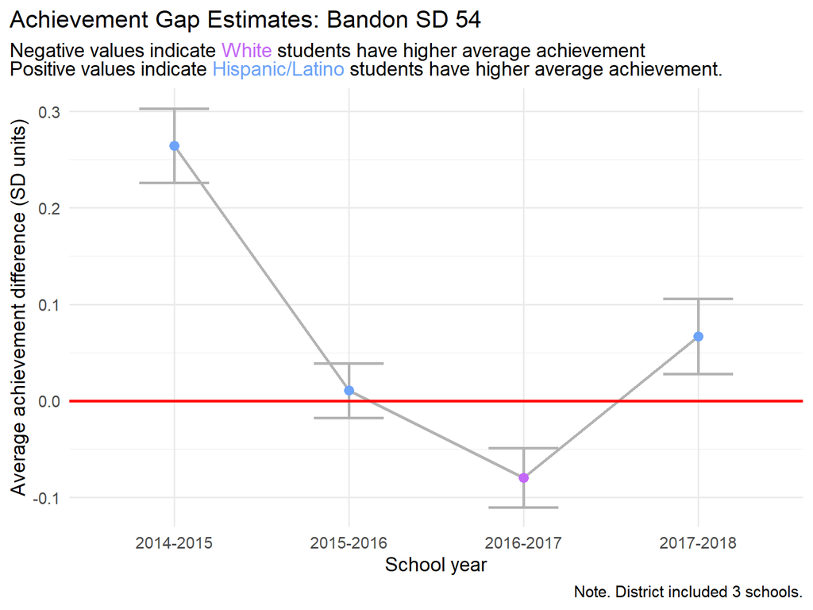

```r
#create column that is the caption we want:
pd2 <- pd %>%
    mutate(label =
    glue("Note. District included {(n_schools)} schools."),
    title =
    glue("Achievment Gap Estimates: {(district)}"))

#create multiple plot
pd2 <- pd2 %>%
    group_by(district, label) %>%
    nest()

final_plots <- pd2 %>%
    mutate(plots = pmap(list(district, label, data),
    ~ggplot(..3, aes(academic_year, v)) +
      geom_point(aes(color = v > 0)) +
    geom_line(aes(x = as.numeric(as.factor(academic_year))),
              color = "grey70",
              size = 1) +
    geom_errorbar(aes(ymin = v - v_se, ymax = v + v_se),
                  color = "grey70",
                  size = 1,
                  width = 0.4) +
            geom_point(aes(color = v > 0),
                       size = 3) +
      scale_color_manual(values = c("#C468F7", "#6DA3F9")) +
    geom_hline(yintercept = 0, color = "red",
               size = 1) +
    theme(plot.title.position = "plot",
          plot.subtitle = element_markdown(),
          legend.position = "none") +
    labs(x = "School year",
         y = "Average achievement difference (SD units)",
         caption = glue("{..2}"),
         title = glue("Achievement Gap Estimates: {..1}"),
         subtitle = "Negative values indicate <span style = 'color:#C468F7;'>White</span> students have higher average achievement
       Positive values indicate <span style = 'color:#6DA3F9;'>Hispanic/Latino</span> students have higher average achievement.")))


# looking at one of the plots:
final_plots$plots[[8]]
```

### 3. (10 points) Save the plots into a “plots” directory. Make sure the file names are meaningful.

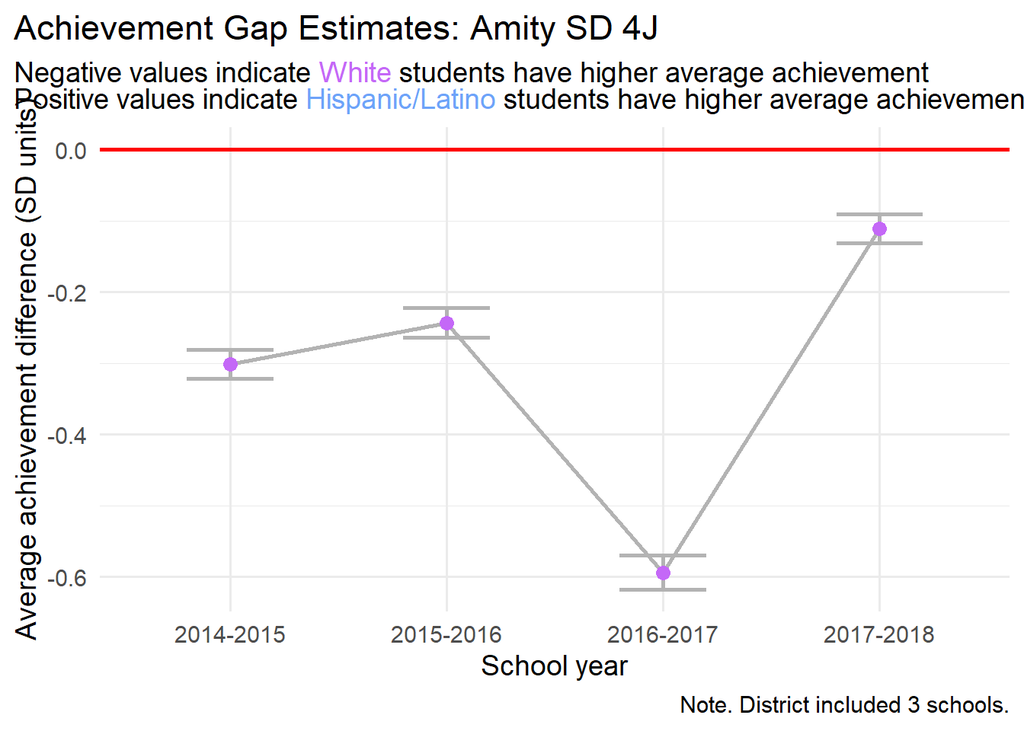

```r
fs::dir_create(here::here("stephanie_plots"))

# trying for first 2 districts to make sure it works:
tmp_final_plots <- final_plots %>%
  filter(district == "Adrian SD 61" |
           district == "Amity SD 4J")

tmp_final_plots$plots[[2]]
```

```r
files <- str_replace_all(tolower(tmp_final_plots$district), " ", "_")
paths <- here::here("stephanie_plots", glue("{files}.png"))

# paths
walk2(paths, tmp_final_plots$plots, ggsave,
       width = 9,
       height = 6,
       dpi = 100)

# generalizing to all files:

files <- str_replace_all(tolower(final_plots$district), " ", "_")
paths <- here::here("stephanie_plots", glue("{files}.png"))
# paths
walk2(paths, final_plots$plots, ggsave,
       width = 9,
       height = 6,
       dpi = 100)
```

[output not shown]